# EDS 223: assignment 2

2023-10-17

## Assignment

### Investigate the legacy of redlining in current environmental (in)justice

**Load relevant packages.**

```r
library(tidyverse)
library(sf)
library(tmap)
library(tmaptools)
library(leaflet)
library(gt)
```

**Read in EJScreen data and filter to Los Angeles County (5 points)**

```r
ejscreen <- st_read("~/Documents/MEDS/Courses/EDS223/Assignment2/assignment-2-hmchilders/data/EJSCREEN_2023_BG_StatePct_with_AS_CNMI_GU_VI.gdb/")
```

**Make a map of wastewater discharge by census block groups. Indicate which census block groups are above the 95th percentile of national values for wastewater discharge by adding a centroid. (10 points)**

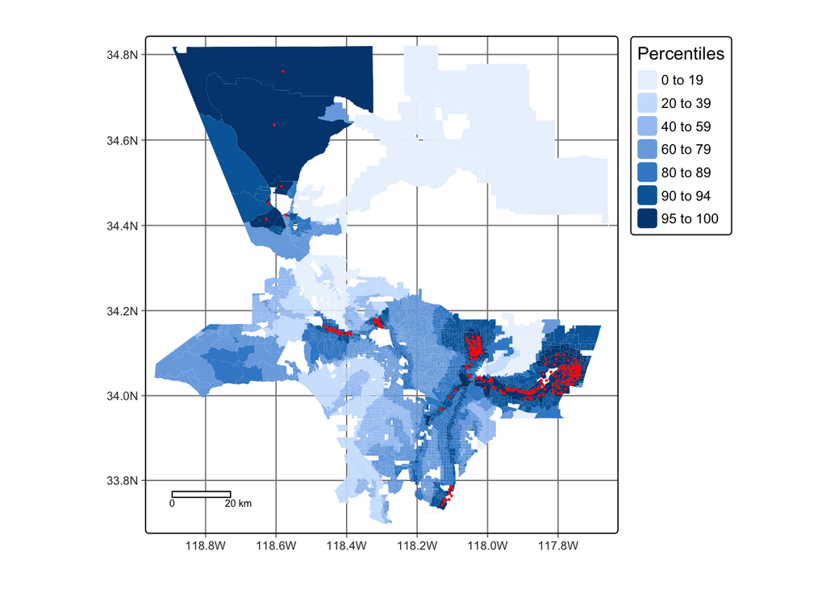

```r
LA <- ejscreen %>%
  filter(CNTY_NAME %in% c("Los Angeles County"))
LA_95 <- LA %>%
  filter(P_PWDIS > 95)

cropped_LA = LA %>%
  drop_na()

tm_shape(cropped_LA)+
  tm_graticules()+
    tm_scale_bar(position = c("left", "bottom"))+
  tm_fill(fill = 'P_PWDIS',
          fill.scale = tm_scale(breaks = c(0,20,40,60,80,90,95,100)),
          fill.legend = tm_legend(title = 'Percentiles'))+
  tm_shape(LA_95)+
  tm_symbols(size = 0.1,
             col = "red")
```

The red centroids represent the 95th percentile census block groups.

Find the percent of census block groups that have:  
- less than 5% of the population is considered low income (5 points)

```r
top_5_income <- LA %>%
  filter(LOWINCPCT < 0.05)

pct_top <- (length(top_5_income$LOWINCPCT)/length(LA$LOWINCPCT))*100
pct_top
```

```
## [1] 6.114398
```

6.11% of the census block groups have less that 5% of the population considered low income.

Find the percent of census block groups that are:  
- above the 80th percentile for Particulate Matter 2.5 AND  
- above the 80th percentile for Superfund proximity (10 points)

```r
pctl_80 <- LA %>%
  filter(P_PM25 > 80 & P_PNPL > 80)

pct_above_80 <- (nrow(pctl_80)/nrow(LA))*100

pct_above_80
```

```
## [1] 17.357
```

17.35% of census block groups are above the 80th percentile for both PM 2.5 and Superfund proximity.

**Import redlining information for Los Angeles.**

```r
LA_redlining <- st_read("https://dsl.richmond.edu/panorama/redlining/static/downloads/geojson/CALosAngeles1939.geojson") %>%
  st_make_valid()
```

**Make a map of historical redlining boundaries, colored by HOLC grade. (5 points)**

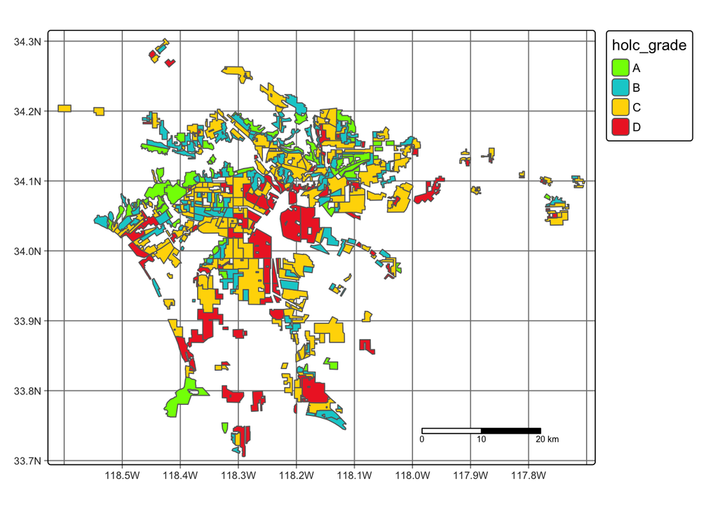

```r
  tm_shape(LA_redlining)+
  tm_graticules()+
    tm_scale_bar()+
  tm_polygons('holc_grade',
          palette = c("chartreuse", "darkturquoise", "gold1", "firebrick2"))
```

**Find the number of census block groups that fall within areas with HOLC grades hint: make sure the CRS match (15 points)**

```r
#Check the crs matching using the commented out code as shown below:
#st_scr(data 1) == st_crs(data 2)

LA_transform <- st_transform(LA_redlining, crs = 3857)

joined_mapping <- st_intersection(LA_transform, LA)

nrow(joined_mapping)
```

[output not shown]

The number of census block groups that fall within HOLC grade areas is 6090.

Summarize current conditions based on EJScreen data within historical redlining categories using the mean of the following variables:  
-% low income.  
- percentile for particulate Matter 2.5.  
- percentile for low life expectancy.  
- percentile for air toxics cancer risk (20 points)

```r
LA_transform <- st_transform(LA_redlining, crs = 3857)
joined_mapping <- st_intersection(LA_transform, LA)
Summ_stats <- joined_mapping %>%
  st_drop_geometry() %>%
  group_by(holc_grade) %>%
  summarize(avg_pct_LowIncome = mean(LOWINCPCT, na.rm = TRUE),
            avg_pctl_PM25 = mean(P_PM25, na.rm = TRUE),
            avg_pctl_LifeExpt = mean(P_LIFEEXPPCT, na.rm = TRUE),
            avg_pctl_Cancer = mean(P_CANCER, na.rm = TRUE)) %>%
  gt()

Summ_stats
```

| holc_grade | avg_pct_LowIncome | avg_pctl_PM25 | avg_pctl_LifeExpt | avg_pctl_Cancer |
| --- | --- | --- | --- | --- |
| A | 0.1494183 | 72.14222 | 23.73502 | 44.00223 |
| B | 0.2419799 | 76.33145 | 37.37701 | 47.69579 |
| C | 0.3409575 | 78.81780 | 47.88598 | 54.55879 |
| D | 0.3915954 | 80.23254 | 53.05932 | 56.53943 |

**Please write 2-3 sentences reflecting on these results. (5 points)**

Breaking the percentiles down into each HOLC grade shows some troubling statistics about the quality of life differences between grades. For the percent of the population considered low income, the percent in HOLC grade A communities is only 15%. For D grade communities in the same category, the percentage jumps to almost 40%. This trend is true for all of the categories explored in this table including the average percentile for PM2.5 concentration, the average percentile for low life expectancy, and average percentile for cancer risk. Average PM2.5 concentration and average percentile for cancer risk have the smallest differences between A and D groups. This data implies that policy decisions are affecting the “safety ratings” for the HOLC grades, and disadvantaged groups are being targeted.

### Investigate the legacy of redlining in biodiversity observations

**For bird observations from 2022 that fall within neighborhoods with HOLC grades, find the percent of observations within each redlining categories and plot results. hint: make sure that the bird observations have the same CRS as redlining data. (20 points)**

```r
bird_data <- st_read("~/Documents/MEDS/Courses/EDS223/Assignment2/assignment-2-hmchilders/data/gbif-birds-LA/")
birds <- bird_data %>%
  filter(year == "2022")

st_crs(birds) == st_crs(LA_redlining)
```

```
## [1] TRUE
```

```r
joined_birds <- st_join(LA_redlining,birds)
```

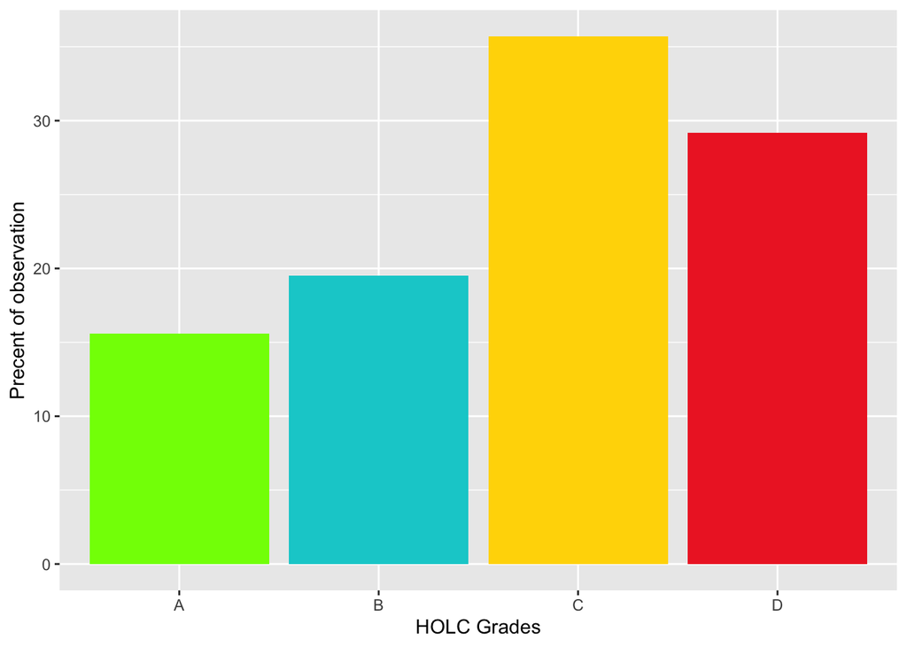

```r
grade_pct <- joined_birds %>%
  group_by(holc_grade) %>%
  summarize(obsv_pct = ((n()/nrow(joined_birds))*100))

ggplot(grade_pct, aes(x = holc_grade, y = obsv_pct))+
  geom_col(fill = c("chartreuse", "darkturquoise", "gold1", "firebrick2"))+
  labs(x = "HOLC Grades",
       y = "Precent of observation")
```

**Please write 2-3 sentences reflecting on these results. Are they surprising? If so, why? What are some potential implications? (5 points)**

These results are not what I would’ve initially expected. I woud’ve expected the majority of the observations to be in A and B grades because the areas are better protected which would encourage bird populations, and the people living in these areas are more affluent and are more likely to spend time bird watching. One reason there might be a higher percentage of sightings in the C and D grade communities is because people living in these areas are more likely to core about the quality of their environment because they are experiencing the effects of increased PM and exposure to toxins.

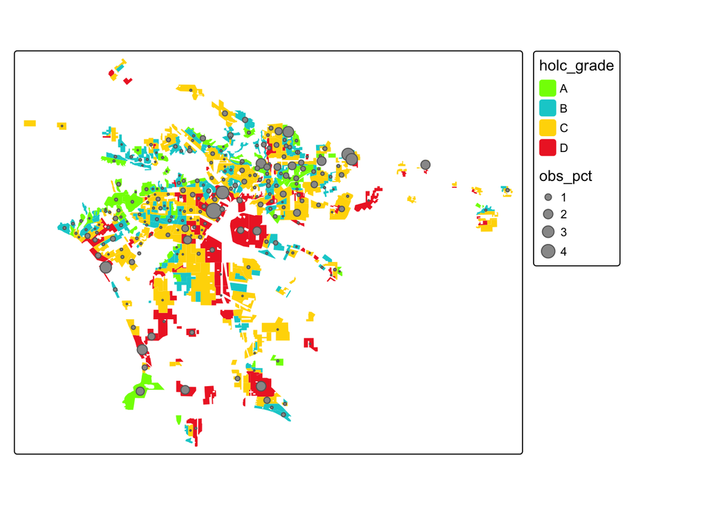

```r
#optional graph
id_pct <-joined_birds %>%
  group_by(holc_id) %>%
  summarize(obs_pct = ((n()/nrow(joined_birds))*100))

tm_shape(LA_redlining)+
  tm_fill('holc_grade',
          palette = c("chartreuse", "darkturquoise", "gold1", "firebrick2" ))+
  tm_shape(id_pct)+
  tm_symbols('obs_pct')
```